# Cyclistic R Case Study - Dan Davis

Here at Cyclistic, we know that we as a bicycle rental company - our best margins come from our subscriptions for annual members. So, knowing we have a large amount of casual riders as well, we would like those casual riders to become members with us. We can conclude that those casual riders are lacking incentive to sign on with us, or else they would have already done so!

We are investigating the following question in this study:

How can we convert our casual riders to be annual members with Cyclistic?

In order to answer this question and find some new angles for our marketing and business development efforts, we are going to take a look at historical sales data for Cyclistic, which is hosted in the AWS bucket at the link below. We should be able to glean some insights from this data to see how we can make annual subscriptions more enticing for our casual riders.

Link to data - https://divvy-tripdata.s3.amazonaws.com/index.html

Below is a description for each column in the datasets:

1. ride_id - Unique hexadecimal code identifying the ride.
2. rideable_type - The type of bike the rider used. Either “classic_bike”, “electric_bike” or “docked_bike”.
3. started_at - Date and time the ride began. ended_at - Date and time the ride concluded.
4. start_station_name - Bike rental location where the ride began.
5. start_station_id - Code for the bike rental location where the ride began.
6. end_station_name - Bike rental location where the ride concluded.
7. end_station_id - Code for the bike rental location where the ride concluded.
8. start_lat - Latitude where the ride began.
9. start_lng - Longitude where the ride began.
10. end_lat - Latitude where the ride ended.
11. end_lng - Longitude where the ride ended.
12. member_casual - Membership type of the rider. Either “member” or “casual”.

Before we begin we will need to make some foundational decisions about our data before we analyze. We can consider this data reliable, original, cited, and comprehensive, but is this data current? We can see the data covers the years 2013-2022. All work done with this data will be protecting the identities of our customers, no identifying information will be in use while conducting this analysis.

An elephant in the room is the COVID-19 pandemic and it’s effect on commuters and remote working. It’s safe to assume a large amount of riders’ normal commuting patterns were disrupted by a big shift to remote work.

If we want to have a look at what our market will actually look like, we’d be wise to only use recent data as a barometer for the commuting market. In order to best reflect this new market condition, we are only going to use the most recent 12 months of data, dating from July 2021 to July 2022.

Due to the size of this dataset (Over 6.7 million rides!), I will be conducting the entirety of my analysis in RStudio Desktop, as BigQuery and RStudioCloud will have limitations due to the size of this data.

```r
#Importing necessary packages
library(tidyverse)
```

```r
library(ggplot2)
library(knitr)
opts_chunk$set(fig.width = 12, fig.height = 8)
```

```r
#Reading the data into tibbles
divvy202107 <- read.csv("C:/Users/Dan/202107-divvy-tripdata.csv")
divvy202108 <- read.csv("C:/Users/Dan/202108-divvy-tripdata.csv")
divvy202109 <- read.csv("C:/Users/Dan/202109-divvy-tripdata.csv")
divvy202110 <- read.csv("C:/Users/Dan/202110-divvy-tripdata.csv")
divvy202111 <- read.csv("C:/Users/Dan/202111-divvy-tripdata.csv")
divvy202112 <- read.csv("C:/Users/Dan/202112-divvy-tripdata.csv")
divvy202201 <- read.csv("C:/Users/Dan/202201-divvy-tripdata.csv")
divvy202202 <- read.csv("C:/Users/Dan/202202-divvy-tripdata.csv")
divvy202203 <- read.csv("C:/Users/Dan/202203-divvy-tripdata.csv")
divvy202204 <- read.csv("C:/Users/Dan/202204-divvy-tripdata.csv")
divvy202205 <- read.csv("C:/Users/Dan/202205-divvy-tripdata.csv")
divvy202206 <- read.csv("C:/Users/Dan/202206-divvy-tripdata.csv")
divvy202207 <- read.csv("C:/Users/Dan/202207-divvy-tripdata.csv")
```

```r
#Combining all the dataframes into one as a dataframe
ridedata <- rbind(divvy202107,divvy202108) %>%
     rbind(divvy202109) %>%
     rbind(divvy202110) %>%
     rbind(divvy202111) %>%
     rbind(divvy202112) %>%
     rbind(divvy202201) %>%
     rbind(divvy202202) %>%
     rbind(divvy202203) %>%
     rbind(divvy202204) %>%
     rbind(divvy202205) %>%
     rbind(divvy202206) %>%
     rbind(divvy202207)
ridedata <- data.frame(ridedata)

#Summary statistics and printing top 5 rows for a first glance at our data
summary(ridedata)
```

```
##    ride_id          rideable_type       started_at          ended_at
##  Length:6723873     Length:6723873     Length:6723873     Length:6723873
##  Class :character   Class :character   Class :character   Class :character
##  Mode  :character   Mode  :character   Mode  :character   Mode  :character
##
##
##
##
##  start_station_name start_station_id   end_station_name   end_station_id
##  Length:6723873     Length:6723873     Length:6723873     Length:6723873
##  Class :character   Class :character   Class :character   Class :character
##  Mode  :character   Mode  :character   Mode  :character   Mode  :character
##
##
##
##
##    start_lat       start_lng         end_lat         end_lng
##  Min.   :41.64   Min.   :-87.84   Min.   :41.39   Min.   :-88.97
##  1st Qu.:41.88   1st Qu.:-87.66   1st Qu.:41.88   1st Qu.:-87.66
##  Median :41.90   Median :-87.64   Median :41.90   Median :-87.64
##  Mean   :41.90   Mean   :-87.65   Mean   :41.90   Mean   :-87.65
##  3rd Qu.:41.93   3rd Qu.:-87.63   3rd Qu.:41.93   3rd Qu.:-87.63
##  Max.   :45.64   Max.   :-73.80   Max.   :42.37   Max.   :-87.49
##                                   NA's   :6321    NA's   :6321
##  member_casual
##  Length:6723873
##  Class :character
##  Mode  :character
##
##
##
##
```

```r
print(head(ridedata))
```

```
##            ride_id rideable_type          started_at            ended_at
## 1 0A1B623926EF4E16   docked_bike 2021-07-02 14:44:36 2021-07-02 15:19:58
## 2 B2D5583A5A5E76EE  classic_bike 2021-07-07 16:57:42 2021-07-07 17:16:09
## 3 6F264597DDBF427A  classic_bike 2021-07-25 11:30:55 2021-07-25 11:48:45
## 4 379B58EAB20E8AA5  classic_bike 2021-07-08 22:08:30 2021-07-08 22:23:32
## 5 6615C1E4EB08E8FB electric_bike 2021-07-28 16:08:06 2021-07-28 16:27:09
## 6 62DC2B32872F9BA8 electric_bike 2021-07-29 17:09:08 2021-07-29 17:15:00
##             start_station_name start_station_id               end_station_name
## 1 Michigan Ave & Washington St            13001   Halsted St & North Branch St
## 2   California Ave & Cortez St            17660           Wood St & Hubbard St
## 3         Wabash Ave & 16th St           SL-012           Rush St & Hubbard St
## 4   California Ave & Cortez St            17660        Carpenter St & Huron St
## 5   California Ave & Cortez St            17660 Elizabeth (May) St & Fulton St
## 6   California Ave & Cortez St            17660  Albany Ave & Bloomingdale Ave
##   end_station_id start_lat start_lng  end_lat   end_lng member_casual
## 1   KA1504000117  41.88398 -87.62468 41.89937 -87.64848        casual
## 2          13432  41.90036 -87.69670 41.88990 -87.67147        casual
## 3   KA1503000044  41.86038 -87.62581 41.89017 -87.62619        member
## 4          13196  41.90036 -87.69670 41.89456 -87.65345        member
## 5          13197  41.90035 -87.69668 41.88659 -87.65839        casual
## 6          15655  41.90033 -87.69674 41.91389 -87.70513        casual
```

Next, we want to take a look at our count of casual riders vs. membership based riders. We can see a breakdown of the counts of each below.

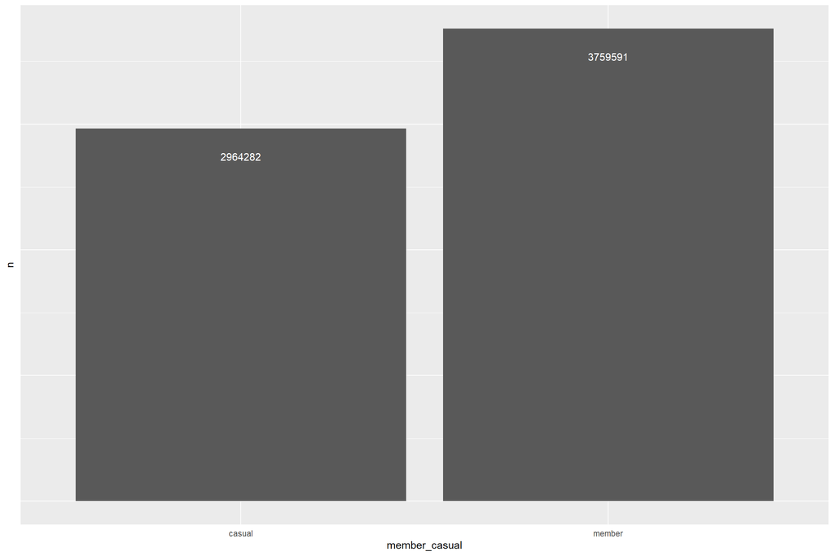

```r
# Making a tibble that just contains the count of each membership type
memberorcasual <- as.data.frame(dplyr::count(ridedata,member_casual,sort=TRUE))

#Quick plot of the results
ggplot(memberorcasual,aes(x=member_casual,y=n))+geom_bar(stat="identity")+geom_text(aes(label=n),vjust=4,color="white")+theme(axis.text.y=element_blank(),axis.ticks.y=element_blank(),axis.ticks.x=element_blank())
```

```r
#Making new dataframes filtering only for casual and member riders
casualriders <- data.frame(filter(ridedata, member_casual=="casual"))
membershipriders <- data.frame(filter(ridedata, member_casual=="member"))
```

A first thing that can give us some ideas about our casual riders is look at the length of their trips vs. that of their membership-holding counterparts. Looking at the time elapsed vs. the distance travelled on these trips will give us the same idea of how people use our bikes, and distance travelled may actually be misleading if a biker is moving in a non-linear path. So we will use the time duration of the trips as our measurement of choice here.

We will start by treating our data by converting it to datetime values for ease of calculation, then performing our calculations, and then plotting them! Below we will start with the data cleaning, and the addition of a new row called “trip_duration”, which is the time elapsed on the trip in seconds.

```r
#Converting our date and time string values to datetime values
casualriders[['started_at']] <- strptime(casualriders[['started_at']],format = "%Y-%m-%d %H:%M:%S")
casualriders[['ended_at']] <- strptime(casualriders[['ended_at']], format = "%Y-%m-%d %H:%M:%S")
membershipriders[['started_at']] <- strptime(membershipriders[['started_at']], format = "%Y-%m-%d %H:%M:%S")
membershipriders[['ended_at']] <- strptime(membershipriders[['ended_at']], format = "%Y-%m-%d %H:%M:%S")

#The distance between the times will be our trip duration in seconds
casualriders <- mutate(casualriders, trip_duration = ended_at - started_at)
membershipriders <- mutate(membershipriders, trip_duration = ended_at - started_at)
```

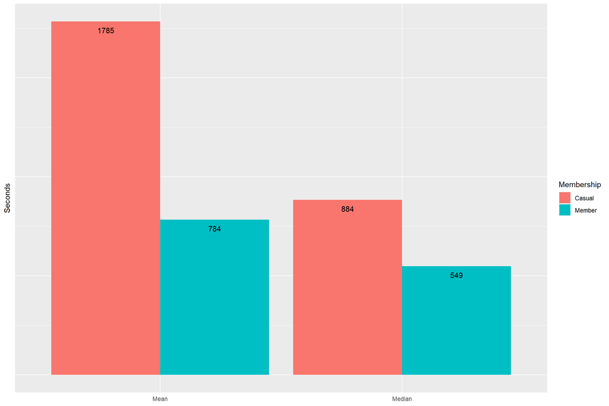

```r
#Initializing a tibble with the means and medians
means <- data.frame(mean(casualriders$trip_duration),mean(membershipriders$trip_duration))
medians <- data.frame(median(casualriders$trip_duration),median(membershipriders$trip_duration))
meansmedians <- tibble(x=c("Casual","Member","Casual","Member"),y=c(means,medians),z=c("Mean","Mean","Median","Median"))
colnames(meansmedians) <- c("Membership","Seconds","Statistic")
meansmedians$Seconds <- as.numeric(meansmedians$Seconds)

#Rounding these values for easier viz
meansmedians$Seconds <- round(meansmedians$Seconds)

#Plotting the data in a stacked bar
ggplot(meansmedians, aes(x=Statistic, y=Seconds, fill = Membership)) + geom_bar(stat="identity", position = "dodge") + geom_text(position=position_dodge(width=.9),aes(label=Seconds,hjust=.5,vjust=2)) + theme(axis.text.y = element_blank(), axis.title.x = element_blank(),
        axis.ticks.y = element_blank(), axis.ticks.x = element_blank())
```

We can see from the plot that our casual riders take over twice as long of rides on average over membership riders, the median ride length is also significantly higher which shows that there isn’t some extremely long distance rides skewing the results.

Another aspect to take a look at is to see what day of the week and time of day are both groups of riders taking their rides? We can use the ride timestamp data to get a look at this below.

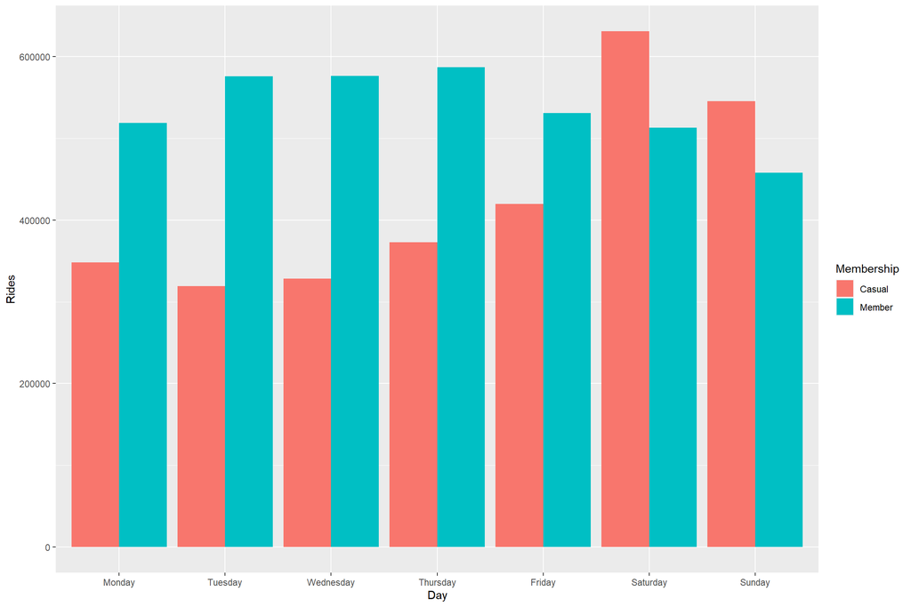

```r
#Takes count of each day, Monday = 1 and Sunday = 7
casualday <- dplyr::count(casualriders,lubridate::wday(casualriders$started_at,week_start=1),sort=FALSE)
memberday <- dplyr::count(membershipriders,lubridate::wday(membershipriders$started_at,week_start=1),sort=FALSE)

#Merges the two tibbles to be plottable
days <- tibble(Day=c("Monday","Tuesday","Wednesday","Thursday","Friday","Saturday","Sunday"),
               Casual=c(casualday$n),
               Member=c(memberday$n))
dayspivot <- pivot_longer(days, -Day)
names(dayspivot) <- c("Day","Membership","Rides")

#Preseres day of week ordering with factor, disables scientific notation for y-axis scaling, plots the result
dayspivot$Day <- factor(dayspivot$Day,levels = c("Monday","Tuesday","Wednesday","Thursday","Friday","Saturday","Sunday"))
options(scipen = 999)
ggplot(dayspivot, aes(x=Day, y=Rides, fill = Membership)) + geom_bar(stat="identity", position = "dodge")
```

As we might expect, membership riders have significantly more rides during weekdays than their casual counterparts. What might be less expected is casual riders activity on weekends, far outriding their membership-bearing counterparts on Saturdays and Sundays.

Along these same lines, let’s now take a look at ridership between the two groups by month below.

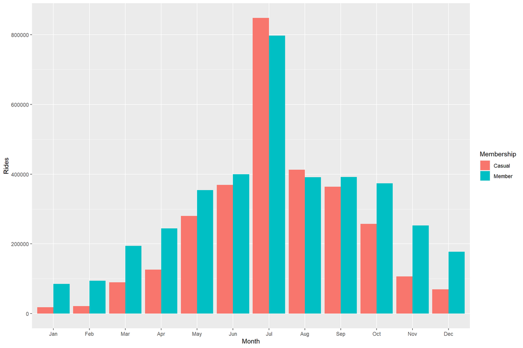

```r
#Takes count of each day, Monday = 1 and Sunday = 7
casualmonth <- dplyr::count(casualriders,lubridate::month(casualriders$started_at),sort=FALSE)
membermonth <- dplyr::count(membershipriders,lubridate::month(membershipriders$started_at),sort=FALSE)

#Merges the two tibbles to be plottable
months <- tibble(Month=c("Jan","Feb","Mar","Apr","May","Jun","Jul","Aug","Sep","Oct","Nov","Dec"),
                 Casual=c(casualmonth$n),
                 Member=c(membermonth$n))
monthspivot <- pivot_longer(months, -Month)
names(monthspivot) <- c("Month","Membership","Rides")

#Preseres day of week ordering with factor, disables scientific notation for y-axis scaling, plots the result
monthspivot$Month <- factor(monthspivot$Month,levels = c("Jan","Feb","Mar","Apr","May","Jun","Jul","Aug","Sep","Oct","Nov","Dec"))
options(scipen = 999)
ggplot(monthspivot, aes(x=Month, y=Rides, fill = Membership)) + geom_bar(stat="identity", position = "dodge")
```

We can see that casual ridership trails membership ridership for all months of the year except July and August. June and September are also strong showings for casual riders relative to membership ones, with the Month of May a bit behind that.

Another item to look at is the bike types. Perhaps there is a difference between two types of riders in their preference of what types of bikes they like to ride. Below we will group the data by the column “rideable_type” to see this breakdown.

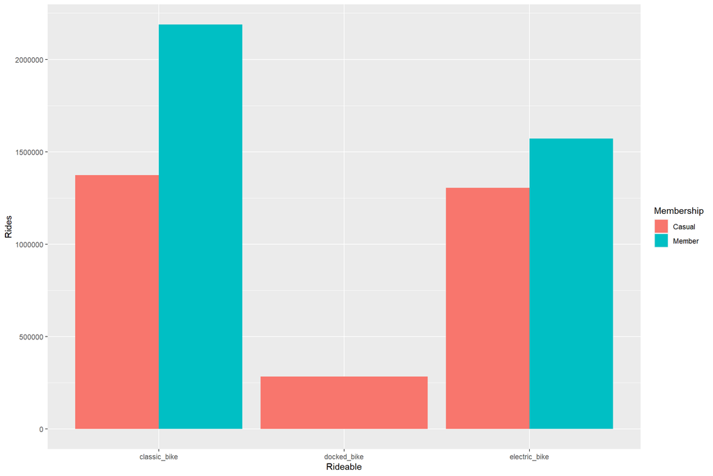

```r
#Counting rideable types by members to start our dataframe
rideabletypes <- dplyr::count(membershipriders,rideable_type,sort=TRUE)

#Tagging the first entries as "Member" so that casual can then be added
rideabletypes <- mutate(rideabletypes,Membership="Member")

#Adding the casual rideable type counts in best format for plotting
rideabletypes <- add_row(rideabletypes,rideable_type=dplyr::count(casualriders,rideable_type,sort=TRUE)$rideable_type,n=dplyr::count(casualriders,rideable_type,sort=TRUE)$n,Membership="Casual")

#Renaming columns for plotting
names(rideabletypes) <- c("Rideable","Rides","Membership")

#Plotting the data
ggplot(rideabletypes, aes(x=Rideable, y=Rides, fill = Membership)) + geom_bar(stat="identity", position = "dodge")
```

Let us display our visualizations again to summarize this case study, and take away some possible ideas for offerings to entice our casual members into a more serious relationship with us.

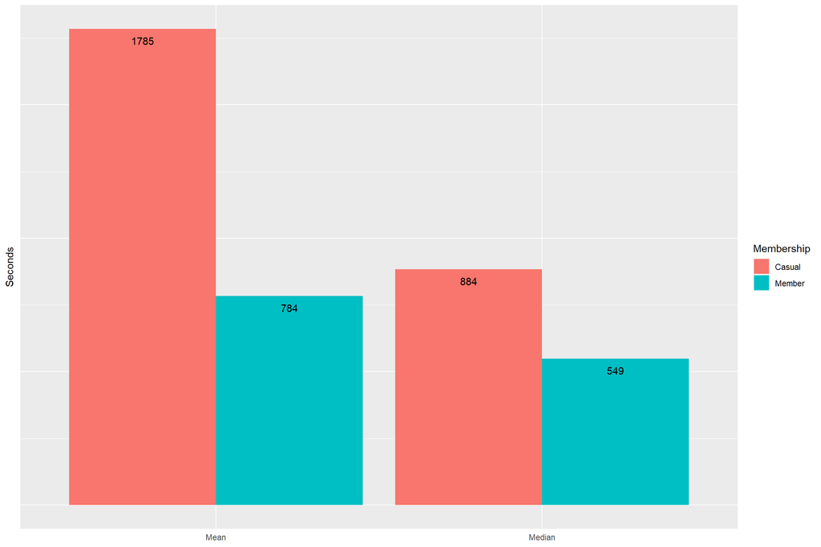

```r
#Trip duration plot
ggplot(meansmedians, aes(x=Statistic, y=Seconds, fill = Membership)) + geom_bar(stat="identity", position = "dodge") + geom_text(position=position_dodge(width=.9),aes(label=Seconds,hjust=.5,vjust=2)) + theme(axis.text.y = element_blank(), axis.title.x = element_blank(),
        axis.ticks.y = element_blank(), axis.ticks.x = element_blank())
```

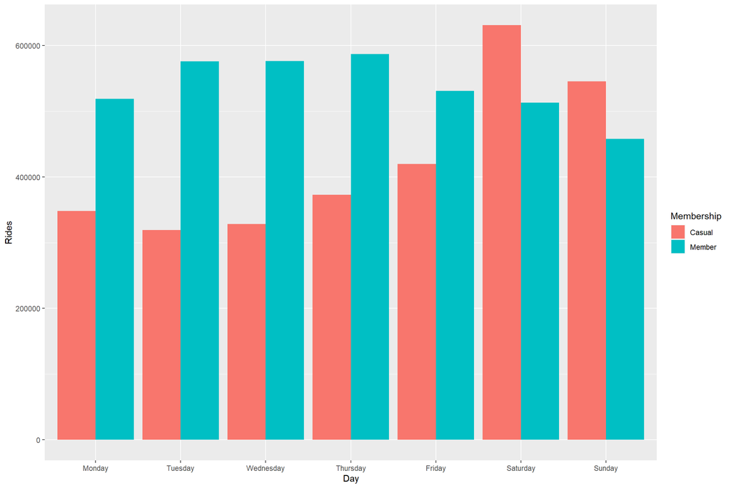

```r
#Days of the week plot
ggplot(dayspivot, aes(x=Day, y=Rides, fill = Membership)) + geom_bar(stat="identity", position = "dodge")
```

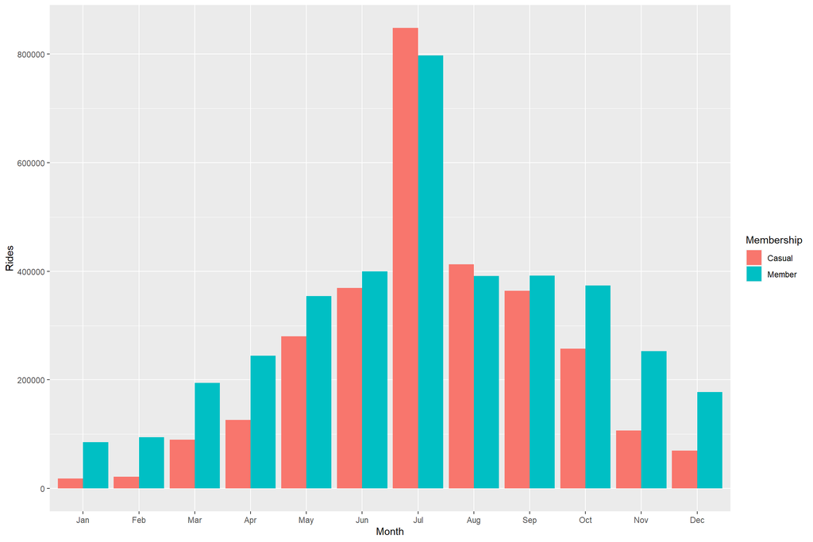

```r
#Months of the year plot
ggplot(monthspivot, aes(x=Month, y=Rides, fill = Membership)) + geom_bar(stat="identity", position = "dodge")
```

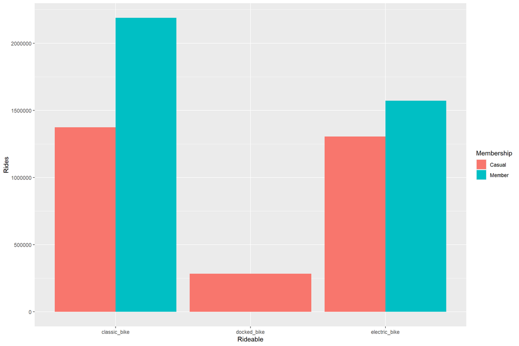

```r
#Types of bikes plot
ggplot(rideabletypes, aes(x=Rideable, y=Rides, fill = Membership)) + geom_bar(stat="identity", position = "dodge")
```

Based on our work here reflected in these visualizations, we can summarize the following things:

Based on the above, we can recommend the following actions:

1. Have events or sweepstakes involving casual riders.
2. Offer discounted memberships or coupons based on having the highest average ride length.
3. Offer weekend-only subscriptions in the hopes of attracting casual riders to be members with us. This rate would need to be priced accordingly; lower than the cost of a full subscription.
4. Offer seasonal memberships, particularly Summer. If there is a cheaper membership only for the busiest months of the year, this may entice people who like currently like using the service casually during the Summer.
5. Investigate the data about docked bikes; either there is an error to correct, or we could offer subscriptions just for our docked bikes to the casual customers that seem to use them frequently.

Thank you for your time and attention, and I hope the insights we were able to discuss here will help Cyclistic grow to it’s full potential!